# Create GitHub README with R Markdown

And visualize your Git history!

Documentation

Package Development

Author

Martin Frigaard

Published

May 31, 2026

GitHub `README` files allow users to introduce themselves, share interests, projects, status, etc.[^1] I love working in RMarkdown, so I wrote a small package that allows me to update my profile `README` with badges and `ggplot2` graphs. I’ll walk through the workflow in this post.

Install the package from GitHub:

```r
install.packages('remotes')
remotes::install_github("mjfrigaard/ghreadme")
```

```r
library(ghreadme)
```

Create a new RMarkdown `README.Rmd` file with the `use_profile_readme()` function:

```r
use_profile_readme(
  name     = "Martin",
  likes    = "#rstats and data visualization.",
  learn    = "Shiny app development, Python, and Linux",
  work     = "R package development tools.",
  collab   = "#rstats packages for data science.",
  username = "mjfrigaard"
)
```

Use `overwrite = TRUE` to replace the existing file.

```bash
✔ Wrote ./README.Rmd
ℹ Edit the placeholders, then knit to regenerate README.md.
```

## Introduce yourself

The [`who_am_i()`](https://mjfrigaard.github.io/ghreadme/reference/who_am_i.html) function can be used to create a .gif of your likes, what you’re currently learning/working on, and how you’d like to connect.

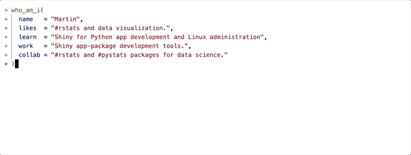

## Collecting Git info

You can collect your Git info with the `collect_git_commits()` function. `include` can also provide commits, stars, issues, and PRs.

```r
stats <- collect_git_commits(
  user    = "your-username",
  emails  = "you@example.com",
  include = c("commits", "stars", "issues", "prs")
)
```

A list with four `tibble`s is returned. Once you have your Git information, you can create graphs for your `README`.

```r
names(stats)
## [1] "commits" "stars"   "issues"  "prs"
```

### Commits

Probably the most interesting data is the `commits` dataset:

```r
str(stats$commits)
## Classes 'tbl_df', 'tbl' and 'data.frame':    2528 obs. of  11 variables:
##  $ repo        : chr  "r-journalism-code-thru" "r-journalism-code-thru" "r-journalism-code-thru" "r-journalism-code-thru" ...
##  $ sha         : chr  "36babd1e3eac9b83e70112ae975a1e0ce68521d9" "33a7a08c3f39c620d79fa3d8eb455eaa5526e796" "aad50f0730ab5c2463c4bcc9eea7458691da4cce" "20964d120b88bb76e9e645f4857702183d3e7300" ...
##  $ timestamp   : POSIXct, format:  ...
##  $ author_name : chr  "Martin Frigaard" "Martin Frigaard" "Martin Frigaard" "Martin Frigaard" ...
##  $ author_email: chr  "mjfrigaard@gmail.com" "mjfrigaard@gmail.com" "mjfrigaard@gmail.com" "mjfrigaard@gmail.com" ...
##  $ message     : chr  "upload data and notebook" "New README .Rmd file" "New text on video" "Merge branch 'master' of https://github.com/mjfrigaard/r-journalism_code_thru" ...
##  $ local_ts    : POSIXct, format:  ...
##  $ date        : Date, format:  ...
##  $ hour        : int  0 8 10 10 10 10 16 16 14 14 ...
##  $ weekday     : Factor w/ 7 levels "Monday","Tuesday",..: 4 4 4 4 4 4 6 6 4 4 ...
##  $ year        : int  2018 2018 2018 2018 2018 2018 2018 2018 2018 2018 ...
```

I’ve included functions in `ghreadme` for quickly making graphs to visualize your commits.

#### Cumulative Line Plot

`cumulative_line_plot()` creates a line graph of the cumulative commits over time per repo:

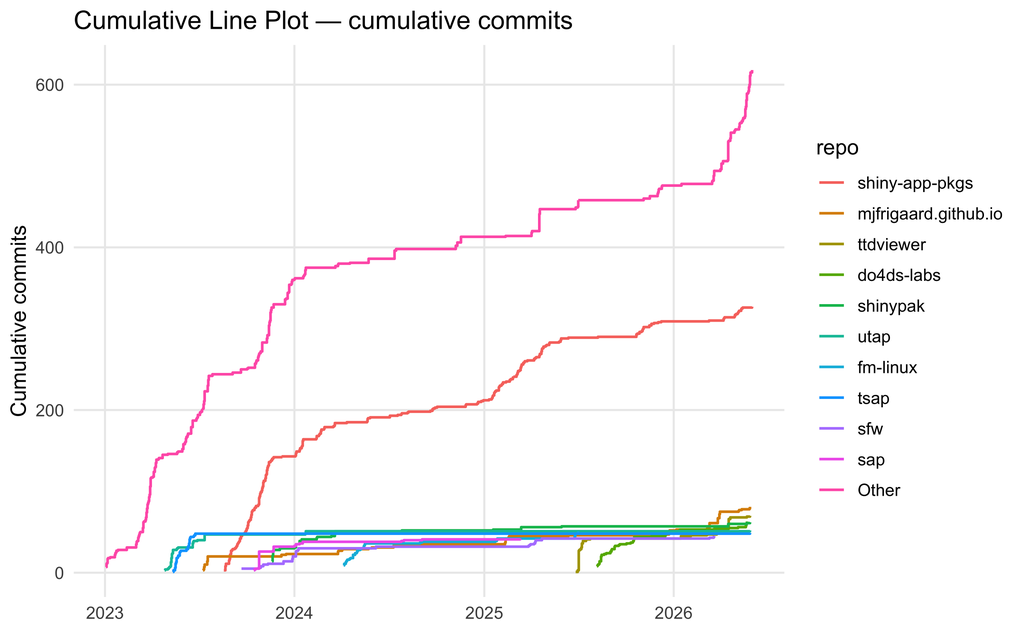

```r
library(ggplot2)

cumulative_line_plot(
  stats$commits,
  repo = NULL,
  date_begin = "2023-01-01",
  date_end = "2026-06-01",
  top_n = 10,
  show_other = TRUE,
  title = "Cumulative Line Plot"
)
```

#### Calendar Heatmap Plot

`calendar_heatmap_plot()` creates a heatmap similar to the GitHub heatmap, and allows us to facet by year.

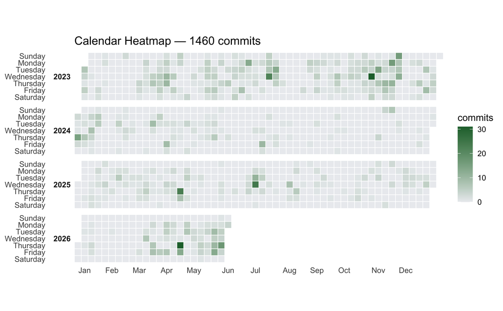

```r
calendar_heatmap_plot(
  stats$commits,
  repo = NULL,
  date_begin = "2023-01-01",
  date_end = "2026-06-01",
  title = "Calendar Heatmap",
  week_start = c("Sunday", "Monday"),
  low = "#ebedf0",
  high = "#216e39"
)
```

#### Punch Card Plot

`punchcard_plot()` lets you view the time of day your commits occur:

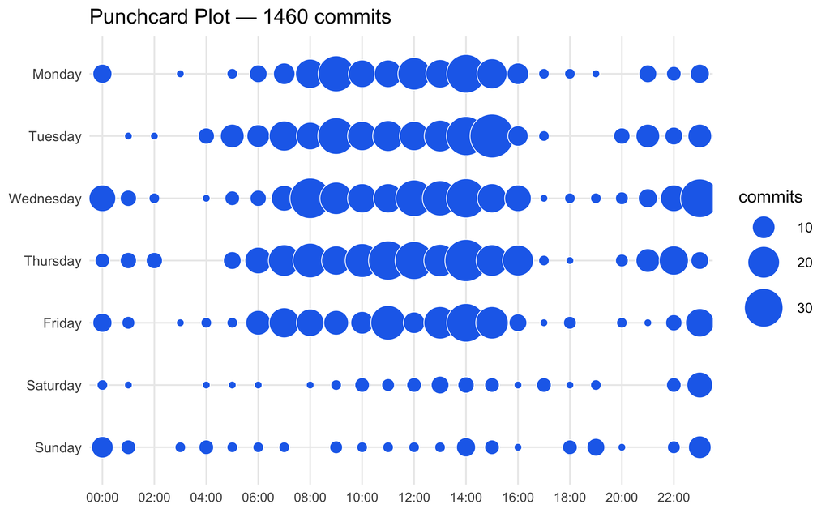

```r
punchcard_plot(
  stats$commits,
  repo = NULL,
  date_begin = "2023-01-01",
  date_end = "2026-06-01",
  title = "Punchcard Plot",
  point_color = "#1f6feb"
)
```

### Stars

The `stars` data has similar structure to the `commits`:

```r
str(stats$stars)
## tibble [155 × 8] (S3: tbl_df/tbl/data.frame)
##  $ repo            : chr [1:155] "shiny-app-pkgs" "sap" "Rsixer" "shinypak" ...
##  $ stargazers_count: int [1:155] 20 6 3 3 2 2 2 2 2 2 ...
##  $ forks_count     : int [1:155] 0 0 0 0 0 0 0 0 0 0 ...
##  $ watchers_count  : int [1:155] 20 6 3 3 2 2 2 2 2 2 ...
##  $ language        : chr [1:155] "HTML" "R" "R" "R" ...
##  $ description     : chr [1:155] "Shiny app-packages (book)" "A collection of {S}hiny {A}pp-{P}ackages" "Shiny, R packages, R6" "R package (code examples for Shiny App-Packages book)" ...
##  $ created_at      : POSIXct[1:155], format:  ...
##  $ updated_at      : POSIXct[1:155], format:  ...
```

#### Top 10 repos by stars

Below is a “Top 10 repos by stars” bar graph using `stargazers_count` and `repo`:

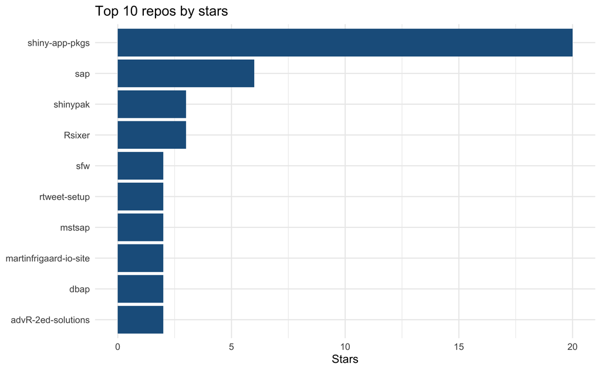

```r
stats$stars |>
  head(10) |>
  ggplot(aes(
    x = stargazers_count,
    y = reorder(repo, stargazers_count)
  )) +
  geom_col(fill = "#1E5F8C") +
  labs(
    x = "Stars",
    y = NULL,
    title = "Top 10 repos by stars"
  ) +
  theme_minimal()
```

### Issues

```r
str(stats$issues)
## tibble [46 × 7] (S3: tbl_df/tbl/data.frame)
##  $ repo      : chr [1:46] "posit-dev/btw" "posit-dev/btw" "mjfrigaard/fm-linux" "mjfrigaard/fm-linux" ...
##  $ number    : int [1:46] 124 122 6 5 4 3 2 1 18 17 ...
##  $ title     : chr [1:46] "btw_app(): parse error: premature EOF" "btw_app(): Error in $: object of type 'closure' is not subsettable" "Basics: update to include users and groups and permissions" "Preface: update outline" ...
##  $ state     : chr [1:46] "closed" "closed" "open" "open" ...
##  $ created_at: POSIXct[1:46], format:  ...
##  $ closed_at : POSIXct[1:46], format:  ...
##  $ url       : chr [1:46] "https://github.com/posit-dev/btw/issues/124" "https://github.com/posit-dev/btw/issues/122" "https://github.com/mjfrigaard/fm-linux/issues/6" "https://github.com/mjfrigaard/fm-linux/issues/5" ...
```

#### Issues per year (by state)

Table outputs are also great for your README. Below is a “issues opened per year, by state” summary:

```r
stats$issues |>
  dplyr::mutate(
    year = as.integer(format(created_at, "%Y"))
    ) |>
  dplyr::count(year, state) |>
  tidyr::pivot_wider(
    names_from = state,
    values_from = n,
    values_fill = 0) |>
  dplyr::arrange(dplyr::desc(year)) |>
  gt::gt() |>
  gt::tab_header(
    title = "Issues opened per year",
    subtitle = "By state")
```

Issues opened per year

By state

| year | closed | open |
| --- | --- | --- |
| 2025 | 8 | 3 |
| 2024 | 5 | 1 |
| 2023 | 10 | 7 |
| 2021 | 3 | 0 |
| 2020 | 3 | 0 |
| 2019 | 0 | 3 |
| 2018 | 1 | 0 |
| 2017 | 0 | 1 |
| 2016 | 1 | 0 |

### Creating .gifs

For changes over time, you can use the recipes in the [visualization vignette](https://mjfrigaard.github.io/ghreadme/articles/viz-git-gif.html) to create animated .gifs. I’ve included examples below.

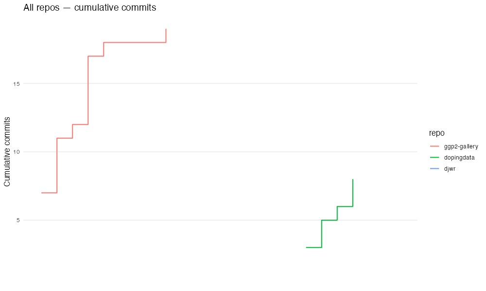

Cumulative Line Plot

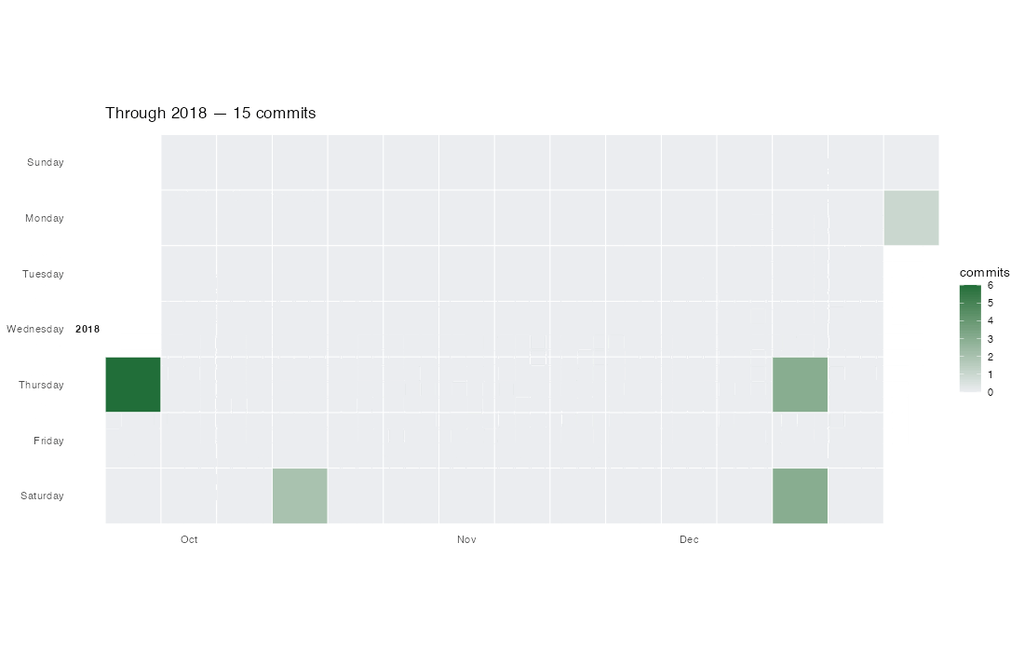

Calendar Heatmap Plot

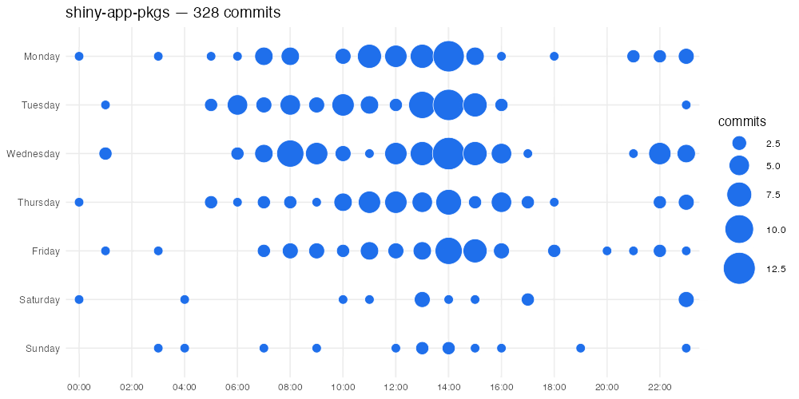

Punch Card Plot

Check out the package documentation for more updates!

## Footnotes

[^1]: Read more about [GitHub README prerequisites](https://docs.github.com/en/account-and-profile/how-tos/profile-customization/managing-your-profile-readme#prerequisites)

[interactive chart not shown]